# Practical Machine Learning Project

Boris Badmaev

September 22, 2015

### Background

Using devices such as Jawbone Up, Nike FuelBand, and Fitbit it is now possible to collect a large amount of data about personal activity relatively inexpensively. These type of devices are part of the quantified self movement - a group of enthusiasts who take measurements about themselves regularly to improve their health, to find patterns in their behavior, or because they are tech geeks. One thing that people regularly do is quantify how much of a particular activity they do, but they rarely quantify how well they do it. In this project, our goal will be to use data from accelerometers on the belt, forearm, arm, and dumbell of 6 participants. They were asked to perform barbell lifts correctly and incorrectly in 5 different ways. More information is available from the website here: http://groupware.les.inf.puc-rio.br/har (see the section on the Weight Lifting Exercise Dataset).

### Data

The training data for this project are available here: https://d396qusza40orc.cloudfront.net/predmachlearn/pml-training.csv

The test data are available here: https://d396qusza40orc.cloudfront.net/predmachlearn/pml-testing.csv

Six young health participants were asked to perform one set of 10 repetitions of the Unilateral Dumbbell Biceps Curl in five different fashions:  
* exactly according to the specification (Class A)  
* throwing the elbows to the front (Class B)  
* lifting the dumbbell only halfway (Class C)  
* lowering the dumbbell only halfway (Class D)  
* throwing the hips to the front (Class E)

Read more: http://groupware.les.inf.puc-rio.br/har#ixzz3mUipvISf

### Assignment

The goal of this project is to predict the manner in which they did the exercise. This is the “classe” variable in the training set. In the next sections We will show how a model was buily, what variables we selected and why in order to build our model and run the predictions. We will also cover the topics of cross validation, what is our estimate of the expected out of sample error. Finally, our prediction model will be used to predict 20 different test cases.

### Data Loading and pre-processing

First, let’s install and load all the necessary packages:

```r
require(lattice)
require(ggplot2)
require(caret)
require(rpart)
require(rpart.plot)
require(randomForest)
```

Secondly, let’s download the data

```r
trainURL<-"https://d396qusza40orc.cloudfront.net/predmachlearn/pml-training.csv"
testURL<-"https://d396qusza40orc.cloudfront.net/predmachlearn/pml-testing.csv"

download.file(trainURL, destfile="pml-training.csv", method="curl", mode="wb")
download.file(trainURL, destfile="pml-testing.csv", method="curl", mode="wb")

training_data<-read.csv("pml-training.csv", header=TRUE, na.strings=c("NA", "", "#DIV/0!"))
testing_data<-read.csv("pml-testing.csv", header=TRUE, na.strings=c("NA", "", "#DIV/0!"))

training_data$classe<-as.factor(training_data$classe)

dim(training_data); dim(testing_data)
```

```
## [1] 19622   160
```

```
## [1]  20 160
```

Exploring the data a lot of NA values were noticed in our dataset. Essentially, some columns are useless for us since almost all the values in them are NA. Let’s get rid of those columns in our training data frame.

```r
#We will remove those columns where NA values are in 90% of the rows
training<-training_data[,!(colSums(is.na(training_data))>=0.9*nrow(training_data))]
```

In addition to that let’s remove the columns that are not related in any way to our outcome: `X`, `user_name`, `raw_timestamp_part_1`, `raw_timestamp_part_2`, `cvtd_timestamp`, `new_window` and `num_window`.

```r
training<-training[, -c(1:7)]
dim(training)
```

```
## [1] 19622    53
```

As we already know the variable `classe` has 5 levels: A,B,C,D,E. Let’s check how these values are distributed across the observations.

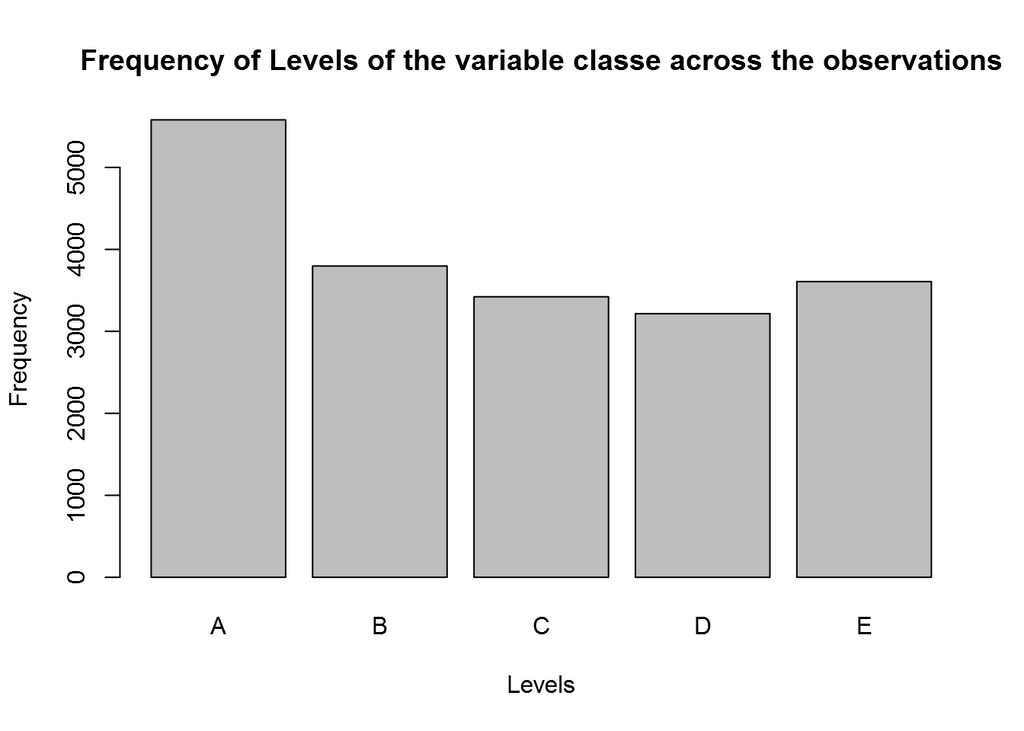

```r
plot(training$classe, main="Frequency of Levels of the variable classe across the observations", xlab="Levels", ylab="Frequency")
```

### Partitioning of training data set for cross-validation

Let’s split our huge training data set ((19622 obs.) into subTraining (70%) and subTesting (30%). We will test our models using subTesting data and select the one with better accuracy and lower expected out-of-sample error.

```r
inTrain<-createDataPartition(y=training$classe, p=0.7, list=FALSE)
subTraining<-training[inTrain,]
subTesting<-training[-inTrain,]
dim(subTraining); dim(subTesting)
```

```
## [1] 13737    53
```

```
## [1] 5885   53
```

### Decision Tree Model

Let’s use `rpart` function to fit a Decision Tree model.

```r
# let's set the seed first
set.seed(2007)
modFit1<-rpart(classe~., data=subTraining, method="class")
```

Let’s take a look at the decision tree

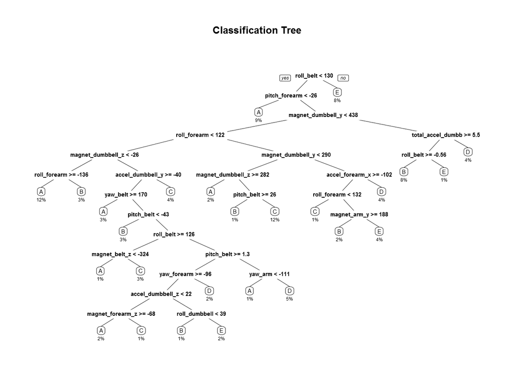

```r
rpart.plot(modFit1, main="Classification Tree", extra=100, under=TRUE, faclen=0)
```

Great! Now, let’s see how well our model can predict the outcome. We will use subTesting data to do this validation

```r
predict1<-predict(modFit1, subTesting, type="class")
confusionMatrix(predict1, subTesting$classe)
```

```
## Confusion Matrix and Statistics
##
##           Reference
## Prediction    A    B    C    D    E
##          A 1521  187   28   55   40
##          B   55  697   72   89  104
##          C   32   99  848  140  101
##          D   27  109   66  615   58
##          E   39   47   12   65  779
##
## Overall Statistics
##
##                Accuracy : 0.7579
##                  95% CI : (0.7467, 0.7688)
##     No Information Rate : 0.2845
##     P-Value [Acc > NIR] : < 2.2e-16
##
##                   Kappa : 0.6928
##  Mcnemar's Test P-Value : < 2.2e-16
##
## Statistics by Class:
##
##                      Class: A Class: B Class: C Class: D Class: E
## Sensitivity            0.9086   0.6119   0.8265   0.6380   0.7200
## Specificity            0.9264   0.9326   0.9234   0.9472   0.9661
## Pos Pred Value         0.8307   0.6853   0.6951   0.7029   0.8270
## Neg Pred Value         0.9623   0.9092   0.9618   0.9303   0.9387
## Prevalence             0.2845   0.1935   0.1743   0.1638   0.1839
## Detection Rate         0.2585   0.1184   0.1441   0.1045   0.1324
## Detection Prevalence   0.3111   0.1728   0.2073   0.1487   0.1601
## Balanced Accuracy      0.9175   0.7723   0.8750   0.7926   0.8430
```

### Random Forest Model

Now, let’s try the Random Forest model

```r
modFit2<-randomForest(classe~.,subTraining,method="class")
# let's use it for prediction on subTesting
predict2<-predict(modFit2, subTesting, type="class")
#show the results
confusionMatrix(predict2, subTesting$classe)
```

```
## Confusion Matrix and Statistics
##
##           Reference
## Prediction    A    B    C    D    E
##          A 1672    3    0    0    0
##          B    2 1133    8    0    0
##          C    0    3 1016    9    0
##          D    0    0    2  955    1
##          E    0    0    0    0 1081
##
## Overall Statistics
##
##                Accuracy : 0.9952
##                  95% CI : (0.9931, 0.9968)
##     No Information Rate : 0.2845
##     P-Value [Acc > NIR] : < 2.2e-16
##
##                   Kappa : 0.994
##  Mcnemar's Test P-Value : NA
##
## Statistics by Class:
##
##                      Class: A Class: B Class: C Class: D Class: E
## Sensitivity            0.9988   0.9947   0.9903   0.9907   0.9991
## Specificity            0.9993   0.9979   0.9975   0.9994   1.0000
## Pos Pred Value         0.9982   0.9913   0.9883   0.9969   1.0000
## Neg Pred Value         0.9995   0.9987   0.9979   0.9982   0.9998
## Prevalence             0.2845   0.1935   0.1743   0.1638   0.1839
## Detection Rate         0.2841   0.1925   0.1726   0.1623   0.1837
## Detection Prevalence   0.2846   0.1942   0.1747   0.1628   0.1837
## Balanced Accuracy      0.9990   0.9963   0.9939   0.9950   0.9995
```

Much better! As expected the Random Forest model produced better predictions.

### Conclusions

We are going to select Random Forest model due to better accuracy results (0.995) compared to Decision Tree method (0.758). The expected out-of-sample error is calculated as 1 - accuracy for predictions made against the cross-validation set, thus our expected out-of-sample error is 0.005 or 0.5%.

### Submission

Now let’s use our model to generate predictions on original Testing data set that contains 20 observations. With 99% accuracy our model is expected to produce pretty accurate results.

```r
# predictions using original testing_data set
predict<-predict(modFit2, testing_data, type="class")
predict
```

```
##  1  2  3  4  5  6  7  8  9 10 11 12 13 14 15 16 17 18 19 20
##  B  A  B  A  A  E  D  B  A  A  B  C  B  A  E  E  A  B  B  B
## Levels: A B C D E
```

```r
# let's prepare files for submission
pml_write_files = function(x){
  n = length(x)
  for(i in 1:n){
    filename = paste0("problem_id_",i,".txt")
    write.table(x[i],file=filename,quote=FALSE,row.names=FALSE,col.names=FALSE)
  }
}
predict<-as.character(predict)
pml_write_files(predict)
```

### References

Velloso, E.; Bulling, A.; Gellersen, H.; Ugulino, W.; Fuks, H. [Qualitative Activity Recognition of Weight Lifting Exercises][1]. Proceedings of 4th International Conference in Cooperation with SIGCHI (Augmented Human ’13) . Stuttgart, Germany: ACM SIGCHI, 2013.

Read more: http://groupware.les.inf.puc-rio.br/har#ixzz3mVA8e840 [1]:http://groupware.les.inf.puc-rio.br/work.jsf?p1=11201